# Sample blog post to learn markdown tips

There’s lots to learn!

Bill Smith

{: .box-success} This is a demo post to show you how to write blog posts with markdown. I strongly encourage you to [take 5 minutes to learn how to write in markdown](https://markdowntutorial.com/) - it’ll teach you how to transform regular text into bold/italics/tables/etc.  
I also encourage you to look at the [code that created this post](https://raw.githubusercontent.com/daattali/beautiful-jekyll/master/_posts/2020-02-28-sample-markdown.md) to learn some more advanced tips about using markdown in Beautiful Jekyll.

**Here is some bold text**

## Here is a secondary heading

[This is a link to a different site](https://deanattali.com/) and this is a link to a section inside this page.

Here’s a table:

| Number | Next number | Previous number |
| --- | --- | --- |
| Five | Six | Four |
| Ten | Eleven | Nine |
| Seven | Eight | Six |
| Two | Three | One |

How about a yummy crepe?

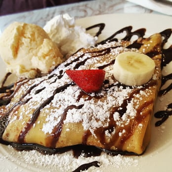

Crepe

It can also be centered!

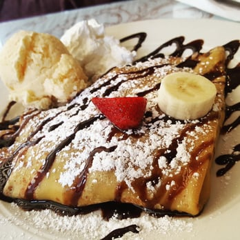

Here’s a code chunk:

```
var foo = function(x) {
  return(x + 5);
}
foo(3)
```

And here is the same code with syntax highlighting:

```javascript
var foo = function(x) {
  return(x + 5);
}
foo(3)
```

## Boxes

You can add notification, warning and error boxes like this:

### Notification

{: .box-note} **Note:** This is a notification box.

### Warning

{: .box-warning} **Warning:** This is a warning box.

### Error

{: .box-error} **Error:** This is an error box.

## Local URLs in project sites

When hosting a *project site* on GitHub Pages (for example, `https://USERNAME.github.io/MyProject`), URLs that begin with `/` and refer to local files may not work correctly due to how the root URL (`/`) is interpreted by GitHub Pages. You can read more about it [in the FAQ](https://beautifuljekyll.com/faq/#links-in-project-page). To demonstrate the issue, the following local image will be broken **if your site is a project site:**

[figure not shown]

Crepe